# week_06_intro_matplotlib

## CMPINF 2100 Fall 2021 - Week 06

### Matplotlib introduction

Essentially why do we need:

`fig, ax = plt.subplots()`

```python
import numpy as np
import pandas as pd
import matplotlib.pyplot as plt
```

## Stateful or MATLAB style

- step 1: initiate the figure
- step 2: specify the subplot that contains the data
- step 3: plot the data
- step 4: show the figure

```python
plt.figure() ### step 1 -- initiate the figure
```

```python
%whos
```

```
Variable   Type      Data/Info
------------------------------
np         module    <module 'numpy' from 'C:\<...>ges\\numpy\\__init__.py'>
pd         module    <module 'pandas' from 'C:<...>es\\pandas\\__init__.py'>
plt        module    <module 'matplotlib.pyplo<...>\\matplotlib\\pyplot.py'>
```

Initiate and now make a simple plot.

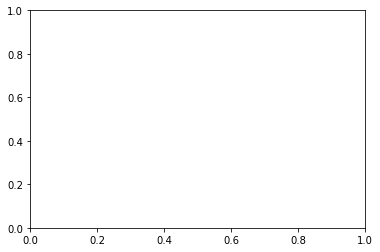

```python
plt.figure()

### create a subplot

plt.subplot(1, 1, 1) ### (number of rows, number of columns, current plot index - panel number)
```

Do this again, reinitate, remake the subplot, and now plot some data.

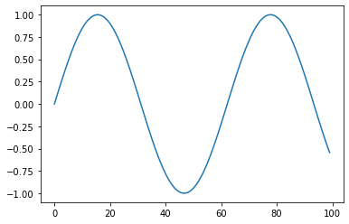

```python
plt.figure()

### create a subplot

plt.subplot(1, 1, 1) ### (number of rows, number of columns, current plot index - panel number)

### plot a sine wave
plt.plot(np.sin(np.linspace(0, 10, 100)))
```

Show the figure.

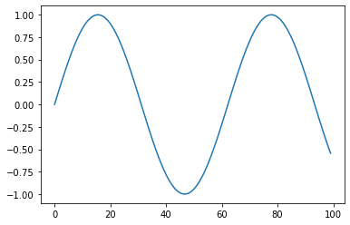

```python
plt.figure()

### create a subplot

plt.subplot(1, 1, 1) ### (number of rows, number of columns, current plot index - panel number)

### plot a sine wave
plt.plot(np.sin(np.linspace(0, 10, 100)))

### show the figure
plt.show()
```

One figure with two subplots. But only make one of the subplots.

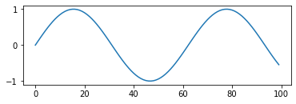

```python
plt.figure()

### create the first subplot on a grid of 2 rows and 1 column
plt.subplot(2, 1, 1)

### plot the data
plt.plot(np.sin(np.linspace(0, 10, 100)))

### show the plot

plt.show()
```

Now make both subplots.

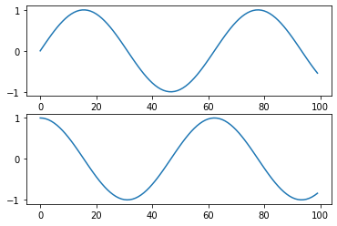

```python
plt.figure()

### create the first subplot on a grid of 2 rows and 1 column
plt.subplot(2, 1, 1)

### plot the data
plt.plot(np.sin(np.linspace(0, 10, 100)))

### create the second subplot on a grid of 2 rows and 1 column
plt.subplot(2, 1, 2)

### plot the data on the second subplot
plt.plot(np.cos(np.linspace(0, 10, 100)))

### show the plot

plt.show()
```

```python
np.linspace(0, 10, 100)
```

```
array([ 0.        ,  0.1010101 ,  0.2020202 ,  0.3030303 ,  0.4040404 ,
        0.50505051,  0.60606061,  0.70707071,  0.80808081,  0.90909091,
        1.01010101,  1.11111111,  1.21212121,  1.31313131,  1.41414141,
        1.51515152,  1.61616162,  1.71717172,  1.81818182,  1.91919192,
        2.02020202,  2.12121212,  2.22222222,  2.32323232,  2.42424242,
        2.52525253,  2.62626263,  2.72727273,  2.82828283,  2.92929293,
        3.03030303,  3.13131313,  3.23232323,  3.33333333,  3.43434343,
        3.53535354,  3.63636364,  3.73737374,  3.83838384,  3.93939394,
        4.04040404,  4.14141414,  4.24242424,  4.34343434,  4.44444444,
        4.54545455,  4.64646465,  4.74747475,  4.84848485,  4.94949495,
        5.05050505,  5.15151515,  5.25252525,  5.35353535,  5.45454545,
        5.55555556,  5.65656566,  5.75757576,  5.85858586,  5.95959596,
        6.06060606,  6.16161616,  6.26262626,  6.36363636,  6.46464646,
        6.56565657,  6.66666667,  6.76767677,  6.86868687,  6.96969697,
        7.07070707,  7.17171717,  7.27272727,  7.37373737,  7.47474747,
        7.57575758,  7.67676768,  7.77777778,  7.87878788,  7.97979798,
        8.08080808,  8.18181818,  8.28282828,  8.38383838,  8.48484848,
        8.58585859,  8.68686869,  8.78787879,  8.88888889,  8.98989899,
        9.09090909,  9.19191919,  9.29292929,  9.39393939,  9.49494949,
        9.5959596 ,  9.6969697 ,  9.7979798 ,  9.8989899 , 10.        ])
```

```python
np.sin( np.linspace(0, 10, 100) )
```

```
array([ 0.        ,  0.10083842,  0.20064886,  0.2984138 ,  0.39313661,
        0.48385164,  0.56963411,  0.64960951,  0.72296256,  0.78894546,
        0.84688556,  0.8961922 ,  0.93636273,  0.96698762,  0.98775469,
        0.99845223,  0.99897117,  0.98930624,  0.96955595,  0.93992165,
        0.90070545,  0.85230712,  0.79522006,  0.73002623,  0.65739025,
        0.57805259,  0.49282204,  0.40256749,  0.30820902,  0.21070855,
        0.11106004,  0.01027934, -0.09060615, -0.19056796, -0.28858706,
       -0.38366419, -0.47483011, -0.56115544, -0.64176014, -0.7158225 ,
       -0.7825875 , -0.84137452, -0.89158426, -0.93270486, -0.96431712,
       -0.98609877, -0.99782778, -0.99938456, -0.99075324, -0.97202182,
       -0.94338126, -0.90512352, -0.85763861, -0.80141062, -0.73701276,
       -0.66510151, -0.58640998, -0.50174037, -0.41195583, -0.31797166,
       -0.22074597, -0.12126992, -0.0205576 ,  0.0803643 ,  0.18046693,
        0.27872982,  0.37415123,  0.46575841,  0.55261747,  0.63384295,
        0.7086068 ,  0.77614685,  0.83577457,  0.8868821 ,  0.92894843,
        0.96154471,  0.98433866,  0.99709789,  0.99969234,  0.99209556,
        0.97438499,  0.94674118,  0.90944594,  0.86287948,  0.8075165 ,
        0.74392141,  0.6727425 ,  0.59470541,  0.51060568,  0.42130064,
        0.32770071,  0.23076008,  0.13146699,  0.03083368, -0.07011396,
       -0.17034683, -0.26884313, -0.36459873, -0.45663749, -0.54402111])
```

Change the total number of subplots.

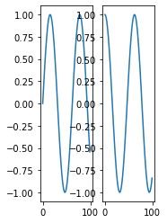

```python
plt.figure()

### create the first subplot on a grid of 2 rows and 1 column
plt.subplot(1, 5, 1)

### plot the data
plt.plot(np.sin(np.linspace(0, 10, 100)))

### create the second subplot on a grid of 2 rows and 1 column
plt.subplot(1, 5, 2)

### plot the data on the second subplot
plt.plot(np.cos(np.linspace(0, 10, 100)))

### show the plot

plt.show()
```

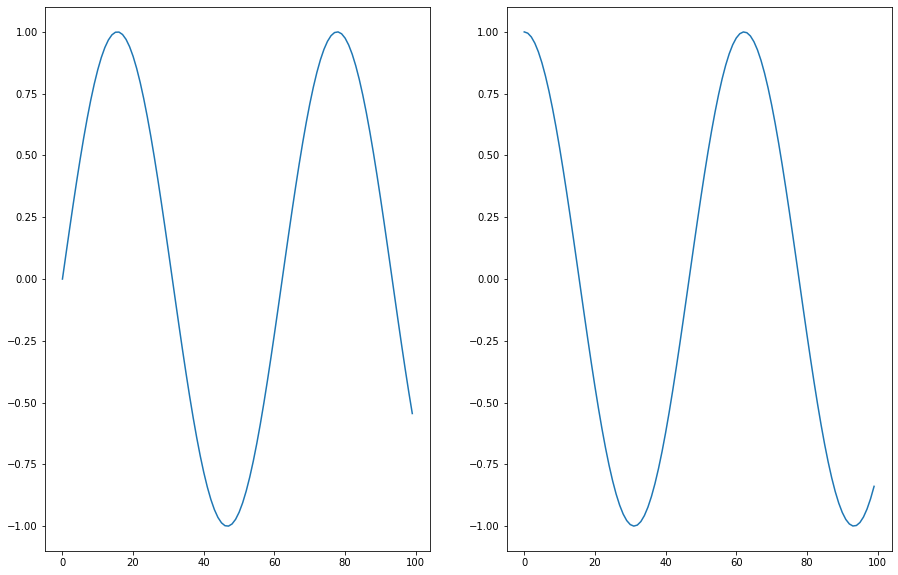

```python
plt.figure(figsize=(40,10))

### create the first subplot on a grid of 2 rows and 1 column
plt.subplot(1, 5, 1)

### plot the data
plt.plot(np.sin(np.linspace(0, 10, 100)))

### create the second subplot on a grid of 2 rows and 1 column
plt.subplot(1, 5, 2)

### plot the data on the second subplot
plt.plot(np.cos(np.linspace(0, 10, 100)))

### show the plot

plt.show()
```

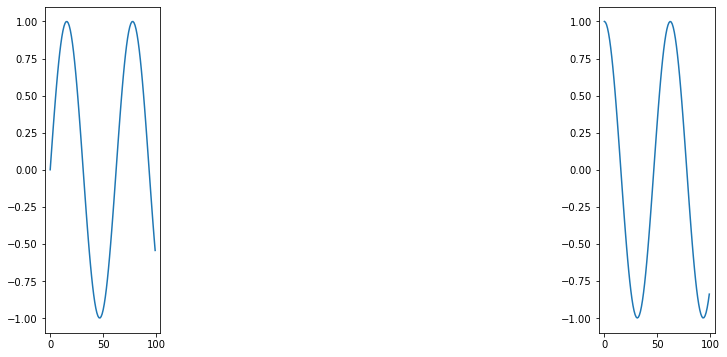

```python
plt.figure(figsize=(12,6))

### create the first subplot on a grid of 2 rows and 1 column
plt.subplot(1, 5, 1)

### plot the data
plt.plot(np.sin(np.linspace(0, 10, 100)))

### create the second subplot on a grid of 2 rows and 1 column
plt.subplot(1, 5, 5)

### plot the data on the second subplot
plt.plot(np.cos(np.linspace(0, 10, 100)))

### show the plot

plt.show()
```

Get the current figure.

```python
plt.gcf()
```

Get the current axis.

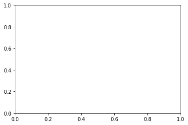

```python
plt.gca()
```

## Object Oriented style

- step 1: define the figure and axes objects
- step 2: plot the data using the methods associated with the axes objects
- step 3: modify axes object attributes (if needed)
- step 4: modify figure object attributes (if needed)
- step 5: show the figure

Make a figure with 2 subplots - or 2 axes on the figure.

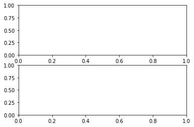

```python
fig, ax = plt.subplots(2)
```

```python
%whos
```

```
Variable   Type       Data/Info
-------------------------------
ax         ndarray    2: 2 elems, type `object`, 16 bytes
fig        Figure     Figure(432x288)
np         module     <module 'numpy' from 'C:\<...>ges\\numpy\\__init__.py'>
pd         module     <module 'pandas' from 'C:<...>es\\pandas\\__init__.py'>
plt        module     <module 'matplotlib.pyplo<...>\\matplotlib\\pyplot.py'>
```

```python
print( type(ax) )
```

```
<class 'numpy.ndarray'>
```

```python
print( type(ax[0]) )
```

```
<class 'matplotlib.axes._subplots.AxesSubplot'>
```

```python
print( type(ax[1]) )
```

```
<class 'matplotlib.axes._subplots.AxesSubplot'>
```

Plot the sin and cos waves on the individual axes.

```python
ax[0].plot(np.sin(np.linspace(0, 10, 100)))
```

```python
ax[1].plot(np.cos(np.linspace(0, 10, 100)))
```

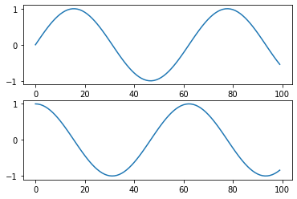

```python
fig
```

Create a grid a of subplots.

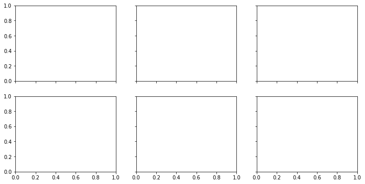

```python
fig, ax = plt.subplots(2, 3, figsize=(12, 6), sharex=True, sharey=True)
```

```python
print( type(ax) )
```

```
<class 'numpy.ndarray'>
```

```python
print( ax.shape )
```

```
(2, 3)
```

```python
print( type(ax[0, 1]) )
```

```
<class 'matplotlib.axes._subplots.AxesSubplot'>
```

```python
for i in range(ax.shape[0]):
    for j in range(ax.shape[1]):
        ax[i, j].text(0.5, 0.5, str((i,j)), ha='center', fontsize=20)
```

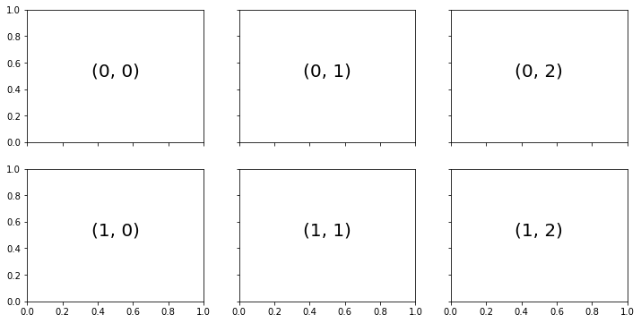

```python
fig
```